# AnalyseSlovaques_JoeMarc_LorraineLarcher_DMDA

## DATA ANALYSIS

Joé Marc & Lorraine Larcher DMDA

Dataset : Etude sur les préférences, intérêts, habitudes, opinions et peurs des slovaques de 15-30 ans

Source : Kaggle

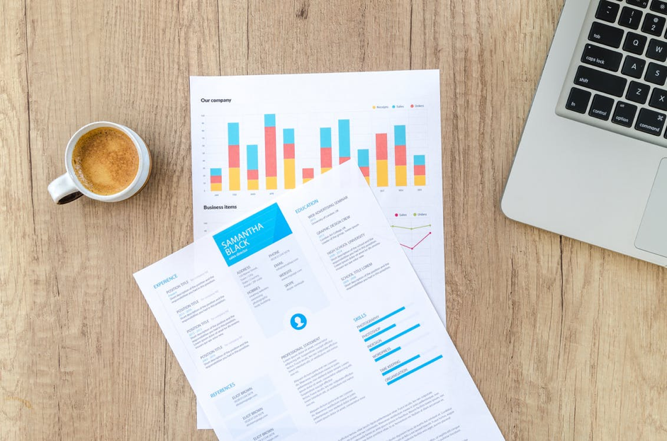

```python
from IPython.display import Image
Image("paper.png")
```

# I. Présentation de notre dataset

Notre dataset date de 2013. C’est un fichier csv. Il porte sur les intérêts, préférences, habitudes, opinions et peurs des jeunes slovaques de 15 à 30 ans. Il a été demandé à ces jeunes de répondre à des questions fermées, en mettant un numéro entre 1 et 5 (1 désaccord à 5 tout à fait d’accord), et des questions ouvertes.

Ce dataset est constitué de 1 010 lignes et 150 colonnes.

```python
# On import différentes librairies qui seront utile à notre projet. (Avant import, les installer avec la commande
# pip ou conda)

import statsmodels.api as sm
%matplotlib inline
import pandas as pd
import copy
import matplotlib.pyplot as plt
import numpy as np
import seaborn as sns
from sklearn import metrics
import itertools as it
```

```python
answers = pd.read_csv("young_responses.csv", sep=";")
answers.head(7)
```

|  | Music | Slow songs or fast songs | Dance | Folk | Country | Classical music | Musical | Pop | Rock | Metal or Hardrock | Punk | Hiphop, Rap | Reggae, Ska | Swing, Jazz | Rock n roll | Alternative | Latino | Techno, Trance | Opera | Movies | Horror | Thriller | Comedy | Romantic | Sci-fi | War | Fantasy/Fairy tales | Animated | Documentary | … |
| --- | --- | --- | --- | --- | --- | --- | --- | --- | --- | --- | --- | --- | --- | --- | --- | --- | --- | --- | --- | --- | --- | --- | --- | --- | --- | --- | --- | --- | --- | --- |
| 0 | 5 | 3 | 2 | 1 | 2 | 2 | 1 | 5 | 5 | 1 | 1 | 1 | 1 | 1 | 3 | 1 | 1 | 1 | 1 | 5 | 4 | 2 | 5 | 4 | 4 | 1 | 5 | 5 | 3 | … |
| 1 | 4 | 4 | 2 | 1 | 1 | 1 | 2 | 3 | 5 | 4 | 4 | 1 | 3 | 1 | 4 | 4 | 2 | 1 | 1 | 5 | 2 | 2 | 4 | 3 | 4 | 1 | 3 | 5 | 4 | … |
| 2 | 5 | 5 | 2 | 2 | 3 | 4 | 5 | 3 | 5 | 3 | 4 | 1 | 4 | 3 | 5 | 5 | 5 | 1 | 3 | 5 | 3 | 4 | 4 | 2 | 4 | 2 | 5 | 5 | 2 | … |
| 3 | 5 | 3 | 2 | 1 | 1 | 1 | 1 | 2 | 2 | 1 | 4 | 2 | 2 | 1 | 2 | 5 | 1 | 2 | 1 | 5 | 4 | 4 | 3 | 3 | 4 | 3 | 1 | 2 | 5 | … |
| 4 | 5 | 3 | 4 | 3 | 2 | 4 | 3 | 5 | 3 | 1 | 2 | 5 | 3 | 2 | 1 | 2 | 4 | 2 | 2 | 5 | 4 | 4 | 5 | 2 | 3 | 3 | 4 | 4 | 3 | … |
| 5 | 5 | 3 | 2 | 3 | 2 | 3 | 3 | 2 | 5 | 5 | 3 | 4 | 3 | 4 | 4 | 5 | 3 | 1 | 3 | 5 | 5 | 5 | 5 | 2 | 3 | 3 | 4 | 3 | 3 | … |
| 6 | 5 | 5 | 5 | 3 | 1 | 2 | 2 | 5 | 3 | 1 | 1 | 3 | 1 | 1 | 2 | 3 | 3 | 5 | 2 | 4 | 2 | 1 | 5 | 3 | 1 | 3 | 5 | 5 | 3 | … |

Les données sont regroupées en 8 grands groupes :

- préférences musicales
- préférences films
- hobbies et intérêts
- phobies
- hygiènes de vie
- traits de personnalités, visions de la vie et opinions
- habitudes de dépenses
- démographie

```python
# On assigne à une variable les colonnes que l'on veut, par type de films, phobies dans notre cas
music = answers.iloc[:,1:19]
movies = answers.iloc[:,19:31]
interests = answers.iloc[:,31:46]
hobbies = answers.iloc[:,46:63]
phobias = answers.iloc[:,63:73]
health = answers.iloc[:,73:76]
traits = answers.iloc[:,76:133]
spending = answers.iloc[:,133:140]
demographics = answers.iloc[:,140:150]
```

```python
type(answers)
```

```
pandas.core.frame.DataFrame
```

Parmis les 150 colonnes, il y a 139 integer et 11 string.

```python
answers.info()
```

```
<class 'pandas.core.frame.DataFrame'>
RangeIndex: 1010 entries, 0 to 1009
Columns: 150 entries, Music to House - block of flats
dtypes: int64(139), object(11)
memory usage: 1.2+ MB
```

```python
answers.count()
```

```
Music                         1010
Slow songs or fast songs      1010
Dance                         1010
Folk                          1010
Country                       1010
Classical music               1010
Musical                       1010
Pop                           1010
Rock                          1010
Metal or Hardrock             1010
Punk                          1010
Hiphop, Rap                   1010
Reggae, Ska                   1010
Swing, Jazz                   1010
Rock n roll                   1010
Alternative                   1010
Latino                        1010
Techno, Trance                1010
Opera                         1010
Movies                        1010
Horror                        1010
Thriller                      1010
Comedy                        1010
Romantic                      1010
Sci-fi                        1010
War                           1010
Fantasy/Fairy tales           1010
Animated                      1010
Documentary                   1010
Western                       1010
                              ...
Public speaking               1010
Unpopularity                  1010
Life struggles                1010
Happiness in life             1010
Energy levels                 1010
Small - big dogs              1010
Personality                   1010
Finding lost valuables        1010
Getting up                    1010
Interests or hobbies          1010
Parents' advice               1010
Questionnaires or polls       1010
Internet usage                1010
Finances                      1010
Shopping centres              1010
Branded clothing              1010
Entertainment spending        1010
Spending on looks             1010
Spending on gadgets           1010
Spending on healthy eating    1010
Age                           1010
Height                        1010
Weight                        1010
Number of siblings            1010
Gender                        1010
Left - right handed           1010
Education                     1010
Only child                    1010
Village - town                1010
House - block of flats        1010
Length: 150, dtype: int64
```

# II. Corrélation

Il serait intéressant de vérifier la corrélation entre les différentes colonnes.

```python
#plt.subplots(figsize=(20,20))
#sns.heatmap(answers.corr(),annot=True)
```

Nous n'emploierons pas cette manière pour analyser la corrélation car elle est illisible en effet la heatmap de seaborn serait plus approprié par la suite pour analyser un petit nombre de colonne, c'est pourquoi nous allons procéder d'une autre manière, grâce à la librairie sklearn.

```python
#on insère dans une variable les différents types de champs.
categories = ['bool', 'int', 'O']
answers_cat = answers[answers.select_dtypes(include=categories).columns]
```

```python
df_categoric = answers_cat.copy()

for col in df_categoric.columns:
    df_categoric[col], _ = pd.factorize(df_categoric[col])
```

```python
from sklearn.metrics import normalized_mutual_info_score
size = df_categoric.columns.size


# On crée une boucle qui pour chaque colonne va la comparer à toute les autres afin d'obtenir le score de corrélation
# grâce à la librairie Sklearn ( mutual info score)
results = np.zeros((size, size))
for i, col1 in enumerate(df_categoric.columns):
    for j, col2 in enumerate(df_categoric.columns):
           results[j,i] = normalized_mutual_info_score(df_categoric[col1], df_categoric[col2])
results = pd.DataFrame(results, index=df_categoric.columns, columns=df_categoric.columns)
```

```python
def plot_matrix(mat):

    # Generate a mask for the upper triangle
    mask = np.zeros_like(mat, dtype=np.bool)
    mask[np.triu_indices_from(mask)] = True

    # Set up the matplotlib figure
    f, ax = plt.subplots(figsize=(30, 20))

    # Generate a custom diverging colormap
    cmap = sns.diverging_palette(220, 10, as_cmap=True)

    # Draw the heatmap with the mask and correct aspect ratio
    sns.heatmap(mat, mask=mask, cmap=cmap,
                #square=True, xticklabels=5, yticklabels=5,
                linewidths=.5, cbar_kws={"shrink": .5}, ax=ax)
```

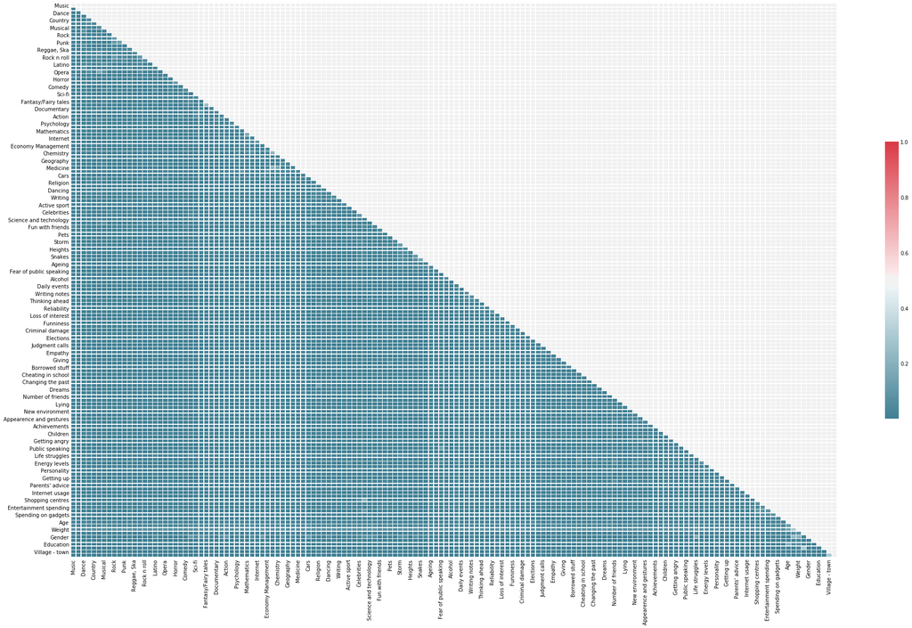

```python
plot_matrix(results)
```

La corrélation est proche de 0 donc il n’y a donc pas de colonnes en double à supprimer.

# III. Problématique

Les slovaques ont-ils les mêmes goûts en termes de films et les mêmes phobies en fonctions de critères démographiques ?

# IV. Limites du dataset

Les limites de notre dataset sont :

- Il contient des valeurs manquantes (nous avons pallié à ce problème en remplissant les celulles vides par le contenu de la cellule au-dessus sur excel)
- Il concerne seulement les slovaques

# V. Analyse générale du dataset

Nous souhaitons en savoir un peu plus sur les slovaques de notre dataset, notamment leur sexe, leur âge et leur lieu d'habitation.

```python
var_of_town = 'Village - town'
mapping = {var_of_town: {'city': 0, 'village': 1}}
answers.dropna(subset=[var_of_town], inplace=True)
# to be able to use hue parameter for better comparison in seaborn
answers["all"] = ""
```

```python
pd.set_option('display.max_columns',150)
plt.style.use('fivethirtyeight')
```

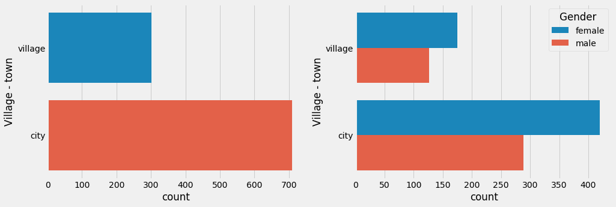

```python
fig, ax = plt.subplots(nrows=1, ncols=2,figsize=(15,5))
sns.countplot(y = var_of_town, data = answers, ax = ax[0])
sns.countplot(y = var_of_town, hue = 'Gender', data = answers, ax = ax[1])
_ = plt.xticks(fontsize=14)
_ = plt.yticks(fontsize=14)
```

```python
var_of_hand = 'Left - right handed'
mapping = {var_of_town: {'Left': 0, 'Right': 1}}
answers.dropna(subset=[var_of_town], inplace=True)
# Pour arriver à utiliser le paramètre afin d'avoir une meilleure comparaison avec seaborn
answers["all"] = ""
```

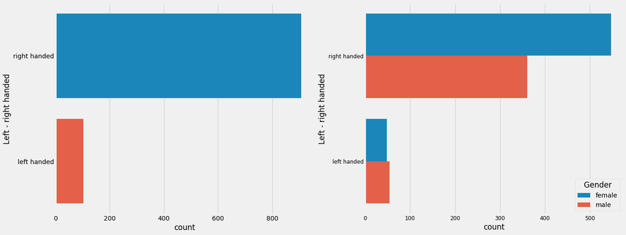

```python
fig, ax = plt.subplots(nrows=1, ncols=2,figsize=(20,8))
sns.countplot(y = var_of_hand, data = answers, ax = ax[0])
sns.countplot(y = var_of_hand, hue = 'Gender', data = answers, ax = ax[1])
_ = plt.xticks(fontsize=12)
_ = plt.yticks(fontsize=12)
```

D'après ce graphique, il y a plus de droitiers que de gauchers dans notre étude. On retrouve davantage de femmes droitières que d'hommes. A l'inverse, bien que les femmes soient plus nombreuses, il y a plus d'hommes gauchers.

```python
demographics['Age'].describe()
```

```
count    1010.000000
mean       20.444554
std         2.835321
min        15.000000
25%        19.000000
50%        20.000000
75%        22.000000
max        30.000000
Name: Age, dtype: float64
```

Dans cette etude, nous avons une moyenne d'âge de 20 ans. Les slovaques interrogés ont entre 15 et 30 ans.

# VI. Analyse poussée du dataset

Analysons maintenant leurs préférences en termes de films et leurs phobies selon des critères tels que :

- le genre
- le sexe
- le lieu d'habitation
- gaucher ou droitier

## A. Films

### 1. Corrélation

Il serait intéressant de vérifier la corrélation entre les colonnes concernant les préférences en termes de films

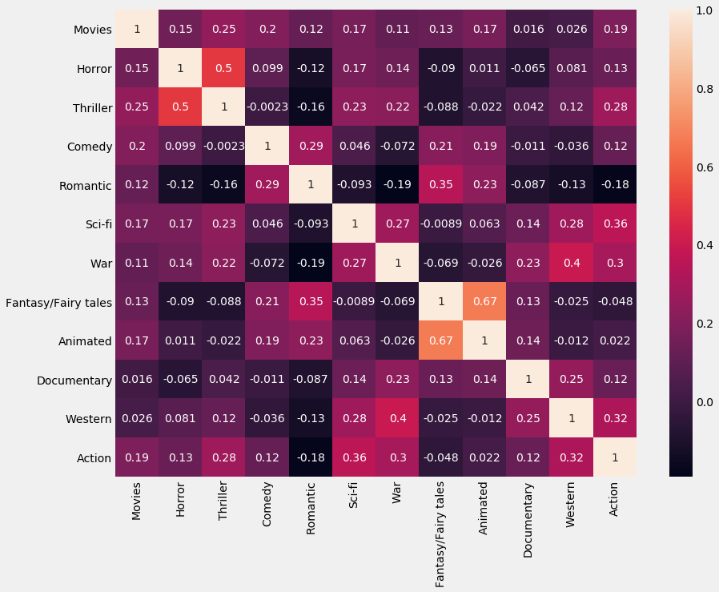

```python
plt.subplots(figsize=(13,10))
sns.heatmap(movies.corr(),annot=True)
```

D'après cette heatmap, nous observons qu'il y a un peu de corrélation entre les champs contenus dans notre variable "movies" de notre dataset. La corrélation est proche de 0 sauf pour les films thriller, horreur, animés et fantaisies. Mais nous décidons de ne pas supprimer les colonnes correspondantes car ce sont des types de films différents et essentiels pour la comparaison.

### 2. Pré-traitement

Pour répondre à notre problématique, nous conservons seulement les colonnes concernant les types de films (19 à 31)

```python
movies = answers.iloc[:,19:31]
movies.head(5)
```

|  | Movies | Horror | Thriller | Comedy | Romantic | Sci-fi | War | Fantasy/Fairy tales | Animated | Documentary | Western | Action |
| --- | --- | --- | --- | --- | --- | --- | --- | --- | --- | --- | --- | --- |
| 0 | 5 | 4 | 2 | 5 | 4 | 4 | 1 | 5 | 5 | 3 | 1 | 2 |
| 1 | 5 | 2 | 2 | 4 | 3 | 4 | 1 | 3 | 5 | 4 | 1 | 4 |
| 2 | 5 | 3 | 4 | 4 | 2 | 4 | 2 | 5 | 5 | 2 | 2 | 1 |
| 3 | 5 | 4 | 4 | 3 | 3 | 4 | 3 | 1 | 2 | 5 | 1 | 2 |
| 4 | 5 | 4 | 4 | 5 | 2 | 3 | 3 | 4 | 4 | 3 | 1 | 4 |

### 3. Type de films préféré

Pour connaître le type de films préféré, nous calculons la moyenne des notes attribuées à chacun

```python
average_movie = movies.mean()
average_movie
```

```
Movies                 4.614851
Horror                 2.793069
Thriller               3.383168
Comedy                 4.494059
Romantic               3.489109
Sci-fi                 3.112871
War                    3.155446
Fantasy/Fairy tales    3.753465
Animated               3.788119
Documentary            3.639604
Western                2.129703
Action                 3.537624
dtype: float64
```

Nous observons que les slovaques préfèrent les films de type "Comédie" avec une moyenne de 4,49 (la colonne "Movies" n'étant bien sur pas à prendre en compte)

Vérifions cela graphiquement

```python
RdGr_cmap = sns.diverging_palette(10, 133, n=5, as_cmap=True)
```

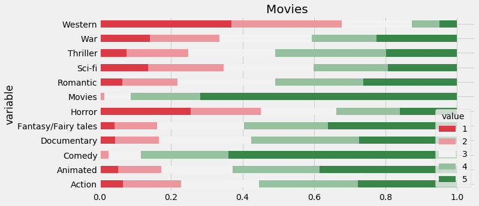

```python
melted = pd.melt(movies)
movie_two_way_table = pd.crosstab(melted['variable'], melted['value'])
movie_percentage = movie_two_way_table.divide(movie_two_way_table.sum(axis=1), axis=0)
_ = movie_percentage.plot.barh(stacked=True, figsize=(10,5), colormap=RdGr_cmap)
_ = _.set_title('Movies', fontsize=20)
```

Ce graphique nous permet d'avoir plus de détails qu'une simple moyenne, en effet nous avons le code couleur pour les notes allant de 1 à 5 ce qui nous permet de voir si il y a un type qui aurait eu plus de 5 mais pas forcément la meilleure moyenne. Ici nous obtenons les mêmes résultats. Le type "Comédie" est le plus apprécié par les slovaques de notre étude.

### 4. Analyse selon différents critères

Il serait intéressant de vérifier si la comédie est le type de films préféré peu importe le sexe, le fait qu'ils soient droitiers ou gauchers et le lieu d'habitation

#### Selon le genre (femme - homme)

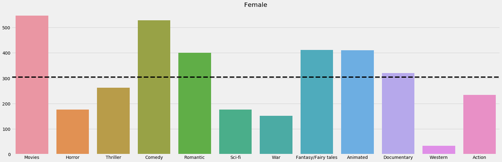

```python
# Femme = 0
# Homme = 1

like = {}
for i in movies.columns:
    df_temp = demographics[movies[i]>=4]
    like[i] = df_temp

female = []
for i in movies.columns:
    female.append(like[i].groupby('Gender').count()['Age'][0])
plt.figure(figsize=(25,8))
plt.title('Female')
plt.axhline(y=np.mean(female), color='k', lw=4, ls='dashed')
sns.barplot(movies.columns,female)
```

Nous observons une nette préférence pour les films de type "Comédie" pour les femmes. Puis suivent les films fantaisies et animés ainsi que les films romantiques.

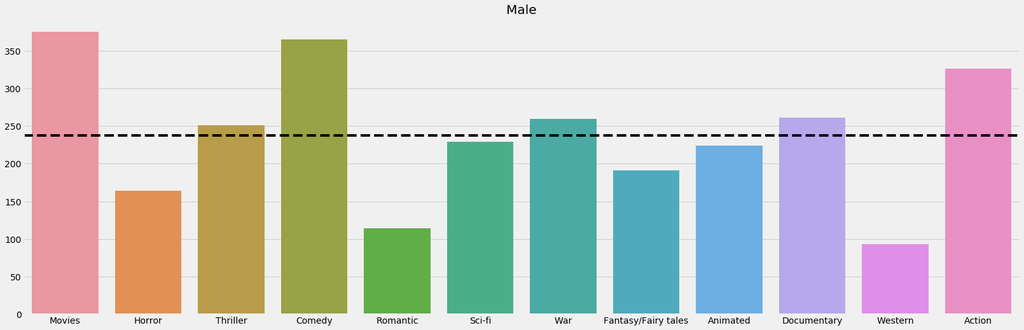

```python
male = []
for i in movies.columns:
    male.append(like[i].groupby('Gender').count()['Age'][1])
plt.figure(figsize=(25,8))
plt.title('Male')
plt.axhline(y=np.mean(male), color='k', lw=4, ls='dashed')
sns.barplot(movies.columns,male)
```

Nous observons une nette préférence pour les films de type "Comédie" pour les hommes. Puis suivent les films d'actions, de guerre, les documentaires et les Thrillers.

Les femmes et les hommes sont davantage intéressés par la "Comédie". Ce qui est surprenant puisqu'on pourrait penser que les hommes préférent les films d'action ou de guerre. Par ailleurs, les femmes et les hommes n'ont pas les mêmes préférences en deuxième position (plutôt fantaisie/animé pour les femmes et plutôt action pour les hommes)

#### Selon le fait qu'ils soient droitier ou gaucher

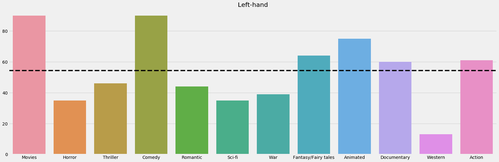

```python
# Gaucher = 0
# Droitier = 1

l = []
for i in movies.columns:
    l.append(like[i].groupby('Left - right handed').count()['Age'][0])
plt.figure(figsize=(25,8))
plt.title('Left-hand')
plt.axhline(y=np.mean(l), color='k', lw=4, ls='dashed')
sns.barplot(movies.columns,l)
```

Nous observons une nette préférence pour les films de type "Comédie" pour les gauchers. Puis suivent les films animés.

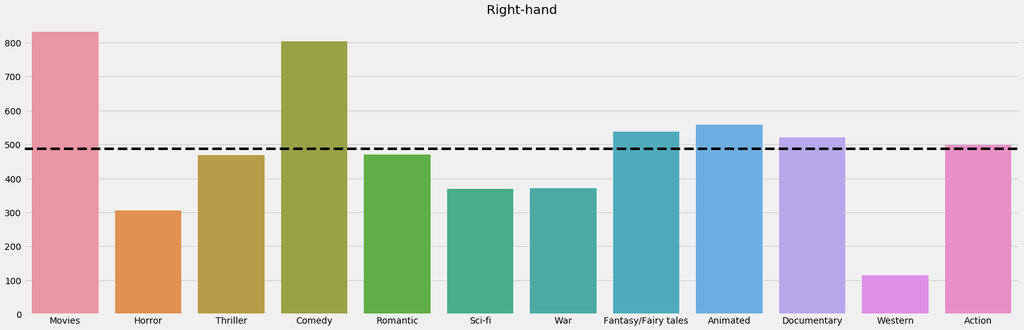

```python
r = []
for i in movies.columns:
    r.append(like[i].groupby('Left - right handed').count()['Age'][1])
plt.figure(figsize=(25,8))
plt.title('Right-hand')
plt.axhline(y=np.mean(r), color='k', lw=4, ls='dashed')
sns.barplot(movies.columns,r)
```

Nous observons une nette préférence pour les films de type "Comédie" pour les droitiers. Puis suivent les films animés. On peut donc constater que puisqu'il y a plus de droitier que de gauchers comme nous l'avons vu au début dans l'analyse générale ou ici dans ce graphique avec le nombre de réponses données, les films préférés ont un meilleur "équilibre" comparé à la main gauche.

Les gauchers et les droitiers sont davantage intéressés par la "Comédie". Ils ont également le même ordre de préférence en ce qui concerne les autres types de films (cela varie très légèrement)

#### Selon le lieu d'habitation (ville - village)

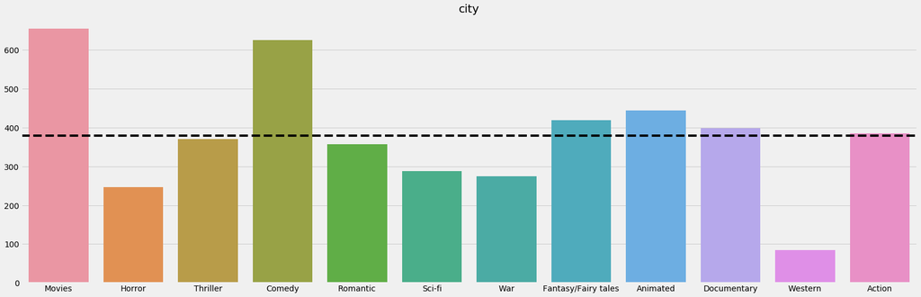

```python
# Ville = 0
# Village = 1

city = []
for i in movies.columns:
    city.append(like[i].groupby('Village - town').count()['Age'][0])
plt.figure(figsize=(25,8))
plt.title('{}'.format(like[i].groupby('Village - town').count()['Age'].index[0]))
plt.axhline(y=np.mean(city), color='k', lw=4, ls='dashed')
sns.barplot(movies.columns,city)
```

Nous observons une nette préférence pour les films de type "Comédie" pour les slovaques habitant en ville. Puis suivent les films animés.

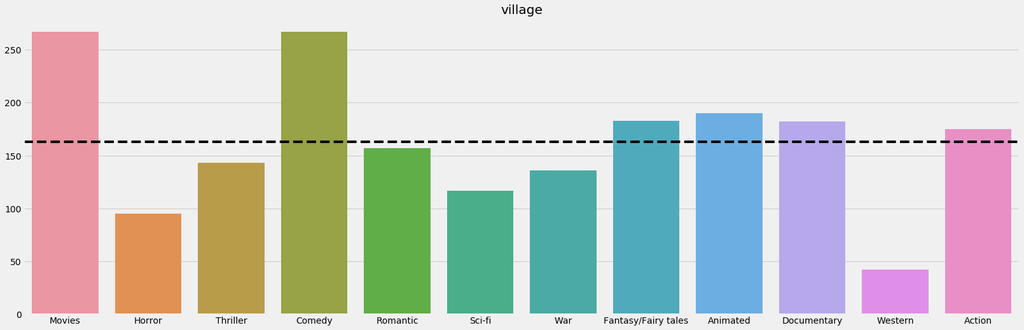

```python
village = []
for i in movies.columns:
    village.append(like[i].groupby('Village - town').count()['Age'][1])
plt.figure(figsize=(25,8))
plt.title('{}'.format(like[i].groupby('Village - town').count()['Age'].index[1]))
plt.axhline(y=np.mean(village), color='k', lw=4, ls='dashed')
sns.barplot(movies.columns,village)
```

Nous observons une nette préférence pour les films de type "Comédie" pour les slovaques habitant à la campagne. Puis suivent les films animés.

Qu'ils habitent en ville ou à la campagne, ils sont davantage intéressés par la "Comédie". Ils ont également le même ordre de préférence en ce qui concerne les autres types de films (cela varie légèrement)

## B. Phobies

### 1. Corrélation

Il serait intéressant de vérifier la corrélation entre les colonnes concernant les phobies

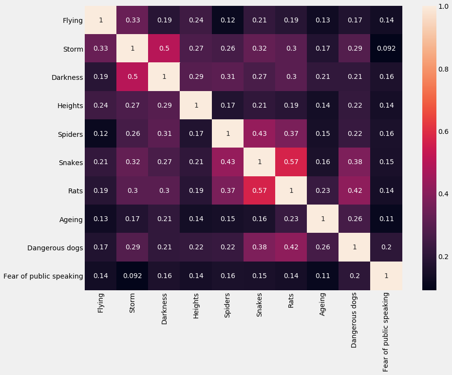

```python
plt.subplots(figsize=(13,10))
sns.heatmap(phobias.corr(),annot=True)
```

D'après cette heatmap, nous observons qu'il y a un peu de corrélation entre les champs contenus dans notre variable "movies" de notre dataset. La corrélation est proche de 0 sauf pour les peurs des tempêtes, du noir, des serpents et des rats. Mais nous décidons de ne pas supprimer les colonnes correspondantes car ce sont des phobies distinctes.

### 2. Pré-traitement

Pour répondre à notre problématique, nous conservons seulement les colonnes concernant les phobies (63 à 73)

```python
phobias = answers.iloc[:,63:73]
phobias.head(5)
```

|  | Flying | Storm | Darkness | Heights | Spiders | Snakes | Rats | Ageing | Dangerous dogs | Fear of public speaking |
| --- | --- | --- | --- | --- | --- | --- | --- | --- | --- | --- |
| 0 | 1 | 1 | 1 | 1 | 1 | 5 | 3 | 1 | 3 | 2 |
| 1 | 1 | 1 | 1 | 2 | 1 | 1 | 1 | 3 | 1 | 4 |
| 2 | 1 | 1 | 1 | 1 | 1 | 1 | 1 | 1 | 1 | 2 |
| 3 | 2 | 1 | 1 | 3 | 5 | 5 | 5 | 4 | 5 | 5 |
| 4 | 1 | 2 | 1 | 1 | 1 | 1 | 2 | 2 | 4 | 3 |

### 3. Phobie la plus terrifiante

Pour connaître la phobie la plus terrifiante, nous calculons la moyenne des notes attribuées à chacune

```python
phobias.mean()
```

```
Flying                     2.061386
Storm                      1.972277
Darkness                   2.253465
Heights                    2.614851
Spiders                    2.829703
Snakes                     3.027723
Rats                       2.410891
Ageing                     2.579208
Dangerous dogs             3.041584
Fear of public speaking    2.804950
dtype: float64
```

Nous observons que les slovaques ont davantage peur des chiens dangereux (3,04) et des serpents (3,03)

Vérifions cela graphiquement

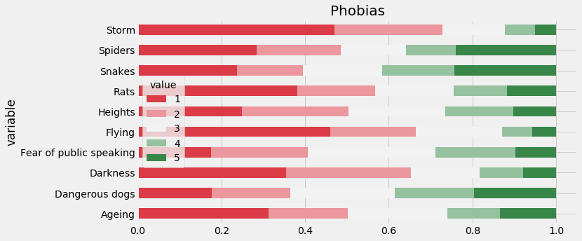

```python
melted = pd.melt(phobias)
phobia_two_way_table = pd.crosstab(melted['variable'], melted['value'])
phobia_percentage = phobia_two_way_table.divide(phobia_two_way_table.sum(axis=1), axis=0)
_ = phobia_percentage.plot.barh(stacked=True, figsize=(10,5), colormap=RdGr_cmap)
_ = _.set_title('Phobias', fontsize=20)
```

Nous obtenons les mêmes résultats. La seule différence est que sur le graphique nous avons une analyse plus détaillée qui nous montre que la phobie la plus intense est celle des serpents. Pour cette dernière, plus de personnes y ont répondu. Concernant la phobie des chiens dangereux, il y a davantage de "grandes notes" (5, 4, 3) ce qui peut biaiser nos résultats avec une simple analyse de la moyenne.

### 4. Analyse selon différents critères

Il serait intéressant de savoir si la peur des serpents reste la plus terrifiante peu importe le sexe, le fait qu'ils soient droitiers ou gauchers et le lieu d'habitation

#### Selon le genre (femme - homme)

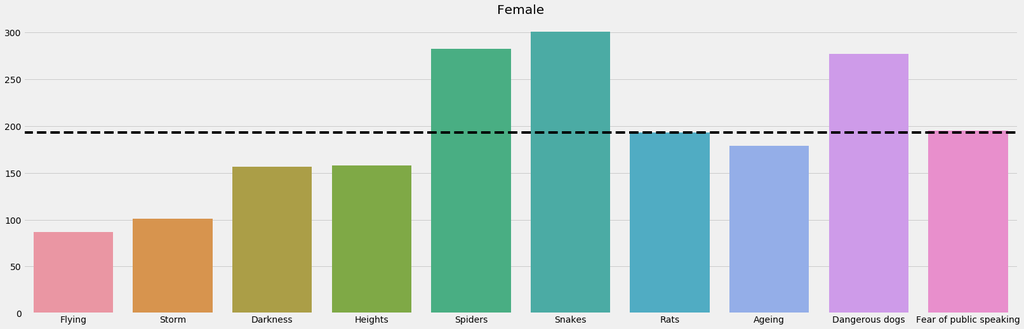

```python
like = {}
for i in phobias.columns:
    df_temp = demographics[phobias[i]>=4]
    like[i] = df_temp

female = []
for i in phobias.columns:
    female.append(like[i].groupby('Gender').count()['Age'][0])
plt.figure(figsize=(25,8))
plt.title('Female')
plt.axhline(y=np.mean(female), color='k', lw=4, ls='dashed')
sns.barplot(phobias.columns,female)
```

Nous observons une phobie plus intense des serpents pour les femmes. Puis suivent celles des arraignées et des chiens dangereux

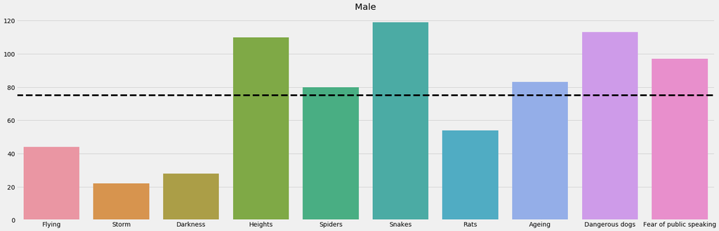

```python
male = []
for i in phobias.columns:
    male.append(like[i].groupby('Gender').count()['Age'][1])
plt.figure(figsize=(25,8))
plt.title('Male')
plt.axhline(y=np.mean(male), color='k', lw=4, ls='dashed')
sns.barplot(phobias.columns,male)
```

#### Selon le fait qu'ils soient droitier ou gaucher

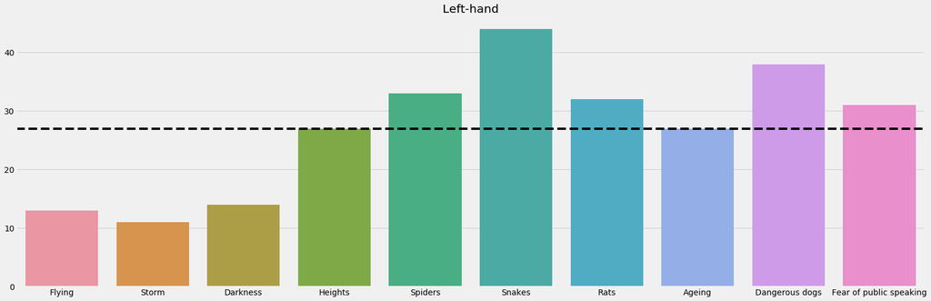

```python
l = []
for i in phobias.columns:
    l.append(like[i].groupby('Left - right handed').count()['Age'][0])
plt.figure(figsize=(25,8))
plt.title('Left-hand')
plt.axhline(y=np.mean(l), color='k', lw=4, ls='dashed')
sns.barplot(phobias.columns,l)
```

Nous observons une phobie plus intense des serpents pour les gauchers. Puis suit celles des chiens dangereux

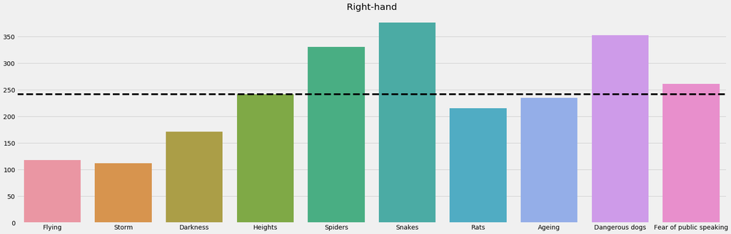

```python
r = []
for i in phobias.columns:
    r.append(like[i].groupby('Left - right handed').count()['Age'][1])
plt.figure(figsize=(25,8))
plt.title('Right-hand')
plt.axhline(y=np.mean(r), color='k', lw=4, ls='dashed')
sns.barplot(phobias.columns,r)
```

Nous observons une phobie plus intense des serpents pour les droitiers. Puis suit celles des chiens dangereux

Les gauchers et les droitiers ont davantage peur des serpents. De plus, ils ont en général le même ordre de phobies. Les gauchers auraient à priori davantage peur des rats et les droitiers des arraignées et du noir

#### Selon le lieu d'habitation (ville - village)

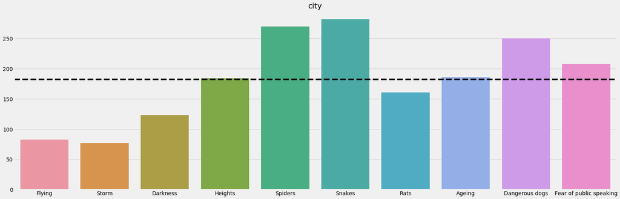

```python
city = []
for i in phobias.columns:
    city.append(like[i].groupby('Village - town').count()['Age'][0])
plt.figure(figsize=(25,8))
plt.title('{}'.format(like[i].groupby('Village - town').count()['Age'].index[0]))
plt.axhline(y=np.mean(city), color='k', lw=4, ls='dashed')
sns.barplot(phobias.columns,city)
```

Nous observons une phobie plus intense des serpents pour les slovaques habitant en ville. Puis suit celles des arraignées

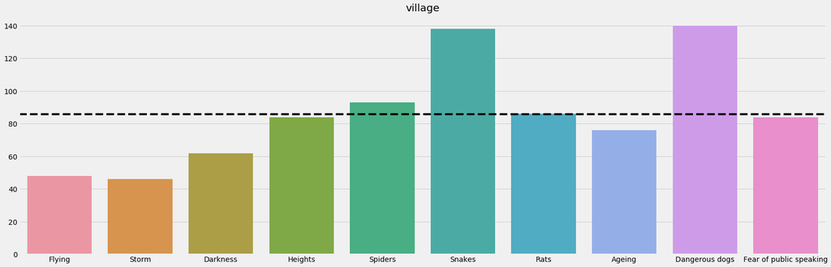

```python
village = []
for i in phobias.columns:
    village.append(like[i].groupby('Village - town').count()['Age'][1])
plt.figure(figsize=(25,8))
plt.title('{}'.format(like[i].groupby('Village - town').count()['Age'].index[1]))
plt.axhline(y=np.mean(village), color='k', lw=4, ls='dashed')
sns.barplot(phobias.columns,village)
```

Nous observons une phobie plus intense des chiens dangereux pour les slovaques habitant à la campagne. Puis suit de très près celles des serpents

Nous obtenons des résultats différents selon leur lieu d'habitation. Ceux venant des campagnes ont très peur des serpents et des chiens dangereux ce qui est moins proéminent pour ceux habitant en ville. Cela peut s'expliquer par le fait qu'à la campagne on trouve davantage ces animaux/insectes.

# VII. Conclusion

Par ailleurs, deux phobies ressortent davantage (serpents et chiens dangereux). Celles-ci sont très importantes quelque soit les critères démographiques. L'une est parfois plus terrifiante que l'autre selon ces critères mais à peu de choses près